# AE 14: Price of diamonds, cont’d

Transforming the response variable

Your Name

2021-10-06

## Price of Diamonds

```r
library(tidyverse)
library(broom)
library(patchwork)
library(knitr)
library(ggfortify)
```

Today’s data set contains the price and characteristics of diamonds. The data are part of the **ggplot2** package. This analysis will focus on the following variables:

- `carat`: Weight of the diamond (in carats)
- `color`: Coded as D (best) through J (worst)
- `price`: price for the diamond (in dollars)

We will focus on diamonds that weight 0.5 carats or less. The goal of this analysis is to use the carat and color to explain variability in the price of diamonds.

```r
diamonds <- ggplot2::diamonds %>%
 filter(carat <= 0.5) %>%
  mutate(color = as.character(color),
         color = factor(color,
                        levels = c("D", "E", "F", "G", "H", "I", "J")))
```

## Review: Mean-centered variables + categorical predictors

### Original model

```r
orig_model <- lm(price ~ carat + color + carat * color, data = diamonds)
tidy(orig_model, conf.int = TRUE) %>%
  kable(digits = 3)
```

| term | estimate | std.error | statistic | p.value | conf.low | conf.high |
| --- | --- | --- | --- | --- | --- | --- |
| (Intercept) | -479.324 | 20.878 | -22.958 | 0.000 | -520.248 | -438.400 |
| carat | 3867.444 | 57.305 | 67.488 | 0.000 | 3755.120 | 3979.768 |
| colorE | 170.565 | 26.185 | 6.514 | 0.000 | 119.240 | 221.889 |
| colorF | 190.792 | 27.676 | 6.894 | 0.000 | 136.545 | 245.039 |
| colorG | 84.368 | 27.812 | 3.034 | 0.002 | 29.854 | 138.883 |
| colorH | 86.044 | 32.281 | 2.666 | 0.008 | 22.771 | 149.317 |
| colorI | 73.166 | 41.189 | 1.776 | 0.076 | -7.568 | 153.901 |
| colorJ | 39.101 | 63.239 | 0.618 | 0.536 | -84.853 | 163.055 |
| carat:colorE | -499.718 | 72.059 | -6.935 | 0.000 | -640.959 | -358.476 |
| carat:colorF | -580.495 | 76.064 | -7.632 | 0.000 | -729.586 | -431.404 |
| carat:colorG | -355.826 | 76.675 | -4.641 | 0.000 | -506.116 | -205.536 |
| carat:colorH | -608.635 | 90.753 | -6.707 | 0.000 | -786.519 | -430.752 |
| carat:colorI | -839.122 | 114.798 | -7.310 | 0.000 | -1064.136 | -614.109 |
| carat:colorJ | -1016.669 | 168.628 | -6.029 | 0.000 | -1347.194 | -686.144 |

### Model using mean-centered `carat`

Let’s use the mean-centered value of `carat` and refit the model.

```r
diamonds <- diamonds %>%
  mutate(caratCent = carat - mean(carat))
```

```r
mean_cent_model <- lm(price ~ caratCent + color + caratCent * color,
                      data = diamonds)
tidy(mean_cent_model, conf.int = TRUE) %>%
  kable(digits = 3)
```

| term | estimate | std.error | statistic | p.value | conf.low | conf.high |
| --- | --- | --- | --- | --- | --- | --- |
| (Intercept) | 892.944 | 3.746 | 238.394 | 0.000 | 885.602 | 900.286 |
| caratCent | 3867.444 | 57.305 | 67.488 | 0.000 | 3755.120 | 3979.768 |
| colorE | -6.748 | 4.849 | -1.392 | 0.164 | -16.252 | 2.756 |
| colorF | -15.183 | 5.089 | -2.983 | 0.003 | -25.157 | -5.208 |
| colorG | -41.888 | 4.879 | -8.585 | 0.000 | -51.451 | -32.324 |
| colorH | -129.916 | 5.594 | -23.223 | 0.000 | -140.881 | -118.950 |
| colorI | -224.576 | 6.699 | -33.522 | 0.000 | -237.707 | -211.445 |
| colorJ | -321.639 | 10.438 | -30.814 | 0.000 | -342.099 | -301.179 |
| caratCent:colorE | -499.718 | 72.059 | -6.935 | 0.000 | -640.959 | -358.476 |
| caratCent:colorF | -580.495 | 76.064 | -7.632 | 0.000 | -729.586 | -431.404 |
| caratCent:colorG | -355.826 | 76.675 | -4.641 | 0.000 | -506.116 | -205.536 |
| caratCent:colorH | -608.635 | 90.753 | -6.707 | 0.000 | -786.519 | -430.752 |
| caratCent:colorI | -839.122 | 114.798 | -7.310 | 0.000 | -1064.136 | -614.109 |
| caratCent:colorJ | -1016.669 | 168.628 | -6.029 | 0.000 | -1347.194 | -686.144 |

### Testing coefficients (Poll)

Let’s use the mean-centered version of the model to answer the following questions:

1. Suppose we wish to test if the mean price for diamonds with color E differs significantly from diamonds with color D. We should use the inferential statistics for which term to conduct this test?
1. Intercept
2. colorE
3. caratCent
4. colorCent:colorE
2. Suppose we wish to test if the effect of carat for diamonds with color E differs significantly from diamonds with color E. We should use the inferential statistics for which term to conduct this test?
1. Intercept
2. colorE
3. caratCent
4. colorCent:colorE
3. What are the degrees of freedom associated with the regression standard error, $\hat{\sigma}$, and thus the degrees of freedom associated with the two tests mentioned above?
1. 18910
2. 18918
3. 18928
4. 18932

## Plot of residuals vs. fitted

Let’s take a look at plots of the residuals.

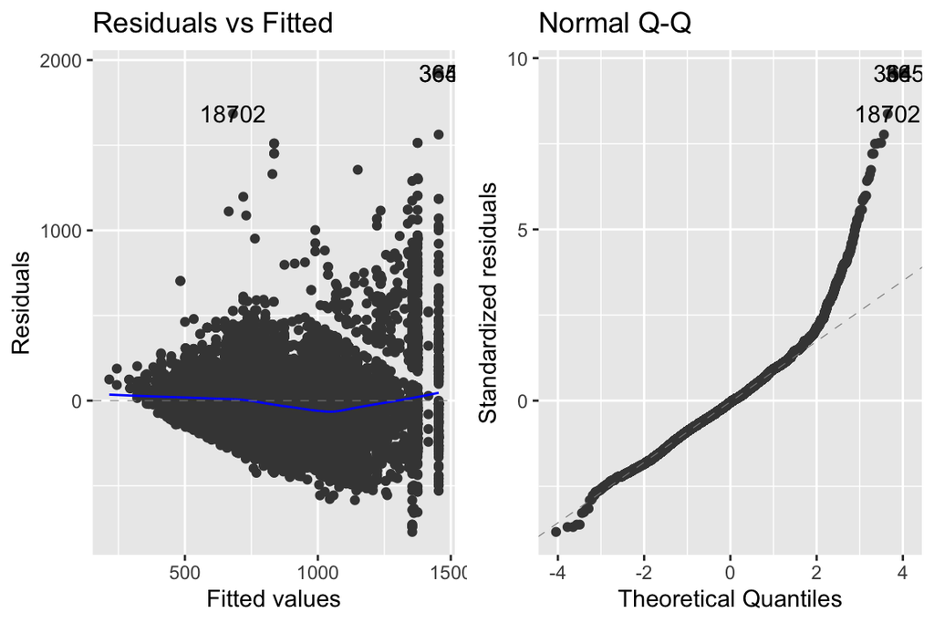

```r
autoplot(mean_cent_model, which = c(1,2))
```

Based on what you learned about conditions for SLR, which condition(s) appear to be violated? *Select all that apply.*

1. Linearity
2. Constant variance
3. Normality
4. Independence

## Log-transformations on the response

Typically, a “fan-shaped” residual plot indicates the need for a transformation of the response variable $y$ - $\log(y)$ is the most straightforward to interpret - When building a model: - Choose a transformation and build the model on the transformed data - Reassess the residual plots - If the residuals plots did not sufficiently improve, try a new transformation!

```r
diamonds <- diamonds %>%
  mutate(log_price = log(price))
```

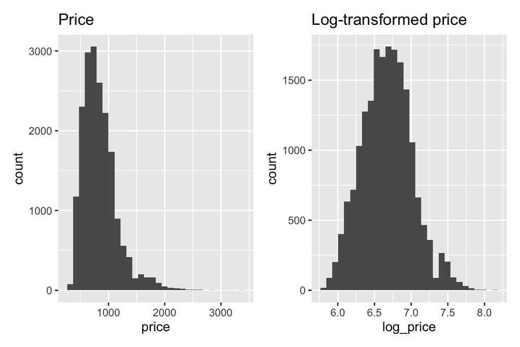

```r
p1 <- ggplot(data = diamonds, aes(x = price)) +
  geom_histogram() +
  labs(title = "Price")

p2 <- ggplot(data = diamonds, aes(x = log_price)) +
  geom_histogram() +
  labs(title = "Log-transformed price")

p1 + p2
```

# Model on log-transformed response

If we apply a log transformation to the response variable, we want to estimate the parameters for the model

$$\log(y_i) = \beta_0 + \beta_1 x_1 + \dots + \beta_p x_p + \epsilon_i, \hspace{5mm} \epsilon_i \sim N(0,\sigma^2_\epsilon)$$

Let’s refit the model using the log-transformed value of price.

```r
log_model <- lm(log_price ~ carat + color + carat*color, data = diamonds)
tidy(log_model, conf.int = TRUE) %>%
  kable(digits = 3)
```

| term | estimate | std.error | statistic | p.value | conf.low | conf.high |
| --- | --- | --- | --- | --- | --- | --- |
| (Intercept) | 5.349 | 0.023 | 236.110 | 0.000 | 5.304 | 5.393 |
| carat | 3.901 | 0.062 | 62.742 | 0.000 | 3.779 | 4.023 |
| colorE | 0.107 | 0.028 | 3.776 | 0.000 | 0.052 | 0.163 |
| colorF | 0.122 | 0.030 | 4.059 | 0.000 | 0.063 | 0.181 |
| colorG | 0.017 | 0.030 | 0.565 | 0.572 | -0.042 | 0.076 |
| colorH | -0.171 | 0.035 | -4.879 | 0.000 | -0.240 | -0.102 |
| colorI | -0.391 | 0.045 | -8.752 | 0.000 | -0.479 | -0.304 |
| colorJ | -0.650 | 0.069 | -9.480 | 0.000 | -0.785 | -0.516 |
| carat:colorE | -0.311 | 0.078 | -3.980 | 0.000 | -0.464 | -0.158 |
| carat:colorF | -0.373 | 0.083 | -4.520 | 0.000 | -0.535 | -0.211 |
| carat:colorG | -0.158 | 0.083 | -1.894 | 0.058 | -0.321 | 0.005 |
| carat:colorH | 0.058 | 0.098 | 0.585 | 0.559 | -0.135 | 0.251 |
| carat:colorI | 0.330 | 0.125 | 2.647 | 0.008 | 0.085 | 0.574 |
| carat:colorJ | 0.624 | 0.183 | 3.408 | 0.001 | 0.265 | 0.982 |

## Residual plots

Before we interpret the coefficients, let’s take another look at the residual plots.

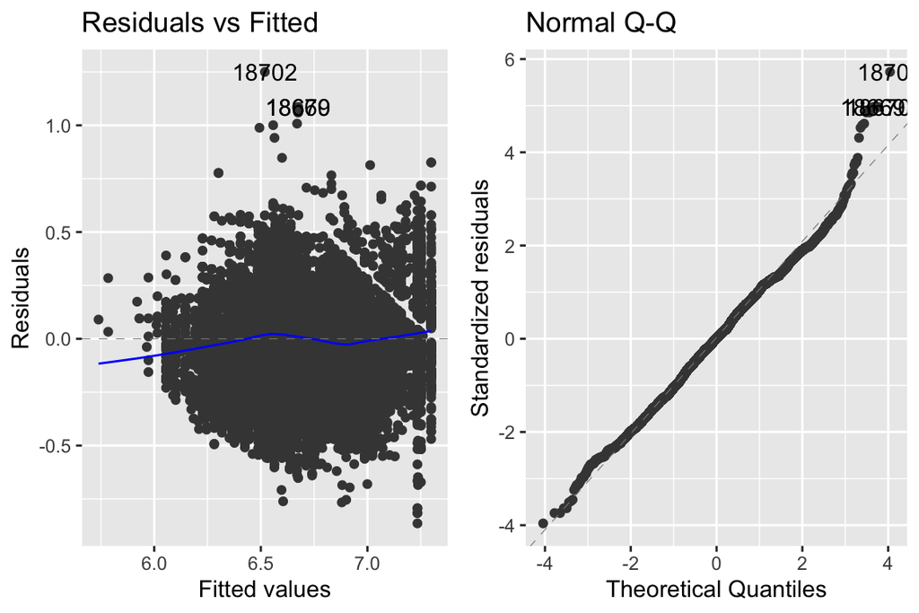

```r
autoplot(log_model, which = c(1,2))
```

## Interpretations in terms of log(price)

The output from R shows the coefficients for the linear model with the response variable $\log(price)$.

1. Interpret the intercept in terms of log(price)
2. Interpret the effect of carat in terms of log(price) for diamonds with color D.

## Interpretations in terms of price

In practice, we want to interpret the coefficients in terms of the original units, not the log-transformed values. Given the regression equation

$$\hat{\log(y_i)} = \hat{\beta}_0 + \hat{\beta}_1 x_1 + \dots + \hat{\beta}_p x_p$$

Then,

$$\begin{aligned}\widehat{Median(y)} &= \exp\{\hat{\beta}_0 + \hat{\beta}_1 x_1 + \dots + \hat{\beta}_p\} \\
&= \exp\{\hat{\beta}_0\}\exp\{\hat{\beta}_1x_1\}\times \dots \times\exp\{\hat{\beta}_px_p\}\end{aligned}$$

**Intercept:** When $x_1 = x_2 = \dots = x_p = 0$ the median of $u$ is expected to be $\exp{\hat{\beta}_0}$

**Slope:** For every one unit increase in $x_j$, the median of $y$ is expected to multiply by a factor of $\exp\{\hat{\beta}_j\}$, holding all else constant.

1. Interpret the intercept in terms of the price.
2. Interpret the effect of carat in terms of price for diamonds with color D.